# NavCity Correlation Analyses with FDR Correction

2025-10-10

# Load Required Libraries

```r
library(tidyverse)
library(broom)
library(knitr)
library(kableExtra)
library(reshape2)
library(corrplot)
```

# Data Import and Preparation

```r
# Load all data files
demographic_data <- read_csv("/Volumes/YB_Drive/NavAging_Paper/data/demographic_data.csv")
non_nav <- read_csv("/Volumes/YB_Drive/NavAging_Paper/data/non_nav_data.csv")
ya_nav <- read_csv("/Volumes/YB_Drive/NavAging_Paper/data/ya_averaged_results.csv")
oa_nav <- read_csv("/Volumes/YB_Drive/NavAging_Paper/data/oa_averaged_results.csv")

# Combine YA and OA navigation data
nav_data <- bind_rows(
  ya_nav %>% mutate(Group = "YA"),
  oa_nav %>% mutate(Group = "OA")
)

# Average navigation metrics across all blocks for each participant
nav_averaged <- nav_data %>%
  group_by(Participant, Group) %>%
  summarise(
    Mean_Speed = mean(Speed, na.rm = TRUE),
    Mean_Distance = mean(Distance, na.rm = TRUE),
    Mean_Navigation_Time = mean(Navigation_Time, na.rm = TRUE),
    .groups = "drop"
  )

# Merge all datasets
merged_temp <- demographic_data %>%
  full_join(non_nav, by = "Participant", suffix = c("_demo", "_non_nav")) %>%
  mutate(Group = coalesce(Group_non_nav,
                          if_else(Group_demo == 1, "YA", "OA"))) %>%
  select(-Group_demo, -Group_non_nav)

merged_data <- merged_temp %>%
  left_join(nav_averaged, by = c("Participant", "Group"))

cat("Total participants:", nrow(merged_data), "\n")
```

```
## Total participants: 60
```

```r
cat("YA participants:", sum(merged_data$Group == "YA", na.rm = TRUE), "\n")
```

```
## YA participants: 30
```

```r
cat("OA participants:", sum(merged_data$Group == "OA", na.rm = TRUE), "\n")
```

```
## OA participants: 30
```

# Create Numeric Variables for Correlation

```r
# Create numeric versions of variables for correlation
merged_data <- merged_data %>%
  mutate(
    # VR Experience already numeric (0, 1, 2)
    VR_Experience_numeric = VR_Experience_Quantified,

    # Calculate Trails B-A difference (switching cost)
    Trails_BA_Diff = Trails_B_CT - Trails_A_CT
  )

# Show coding scheme
cat("Variable Information:\n")
```

```
## Variable Information:
```

```r
cat("- VR Experience: 0 (never), 1 (1-3 times), 2 (>3 times)\n")
```

```
## - VR Experience: 0 (never), 1 (1-3 times), 2 (>3 times)
```

```r
cat("- Video Game Usage: Continuous (hours per week or similar)\n")
```

```
## - Video Game Usage: Continuous (hours per week or similar)
```

```r
cat("- SSS Pre: Stanford Sleepiness Scale baseline (1-7)\n")
```

```
## - SSS Pre: Stanford Sleepiness Scale baseline (1-7)
```

```r
cat("- SBSOD: Santa Barbara Sense of Direction Scale (higher = better)\n")
```

```
## - SBSOD: Santa Barbara Sense of Direction Scale (higher = better)
```

```r
cat("- Trails A: Completion time (lower = better)\n")
```

```
## - Trails A: Completion time (lower = better)
```

```r
cat("- Trails B: Completion time (lower = better)\n")
```

```
## - Trails B: Completion time (lower = better)
```

```r
cat("- Trails B-A: Cognitive switching cost (higher = worse)\n")
```

```
## - Trails B-A: Cognitive switching cost (higher = worse)
```

```r
cat("- Corsi Blocks: Total score (higher = better)\n\n")
```

```
## - Corsi Blocks: Total score (higher = better)
```

```r
# Define predictors and outcomes
predictors <- c(
  "VR_Experience_numeric",
  "Video_Game_Experience_Quantified",
  "SSS_Pre",
  "SBSOD",
  "Trails_A_CT",
  "Trails_B_CT",
  "Trails_BA_Diff",
  "Corsi_Score_Total"
)

predictor_labels <- c(
  "VR Experience",
  "Video Game Usage",
  "SSS Pre",
  "SBSOD",
  "Trails A",
  "Trails B",
  "Trails B-A (Switch Cost)",
  "Corsi Total"
)

outcomes <- c(
  "Mean_Speed",
  "Mean_Distance",
  "Mean_Navigation_Time"
)

outcome_labels <- c(
  "Mean Speed",
  "Mean Distance",
  "Mean Nav Time"
)

cat("8 Predictors × 3 Outcomes = 24 correlations per group\n")
```

```
## 8 Predictors × 3 Outcomes = 24 correlations per group
```

```r
cat("Total correlations: 48 (24 YA + 24 OA)\n")
```

```
## Total correlations: 48 (24 YA + 24 OA)
```

```r
cat("FDR correction applied within each age group (24 tests each)\n")
```

```
## FDR correction applied within each age group (24 tests each)
```

# YA Group Correlations with FDR Correction

```r
cat("=== YOUNGER ADULTS (YA) CORRELATIONS ===\n\n")
```

```
## === YOUNGER ADULTS (YA) CORRELATIONS ===
```

```r
# Filter YA data
ya_data <- merged_data %>% filter(Group == "YA")

cat("YA sample size:", nrow(ya_data), "\n\n")
```

```
## YA sample size: 30
```

```r
# Function to compute correlations
compute_correlations <- function(data, predictors, outcomes) {
  results <- expand_grid(
    predictor = predictors,
    outcome = outcomes
  ) %>%
    mutate(
      correlation = map2(predictor, outcome, function(pred_var, out_var) {
        # Filter to complete cases for this pair
        valid_indices <- !is.na(data[[pred_var]]) & !is.na(data[[out_var]])

        if (sum(valid_indices) < 3) {
          return(tibble(r = NA, p_value = NA, n = 0))
        }

        test <- cor.test(data[[pred_var]][valid_indices],
                        data[[out_var]][valid_indices],
                        method = "pearson")
        tibble(
          r = test$estimate,
          p_value = test$p.value,
          n = sum(valid_indices)
        )
      })
    ) %>%
    unnest(correlation)

  return(results)
}

# Compute all YA correlations
ya_correlations <- compute_correlations(ya_data, predictors, outcomes)

# Add FDR correction within YA group
ya_correlations <- ya_correlations %>%
  mutate(
    p_fdr = p.adjust(p_value, method = "fdr")
  )

# Add labels for better readability
ya_correlations <- ya_correlations %>%
  mutate(
    predictor_label = predictor_labels[match(predictor, predictors)],
    outcome_label = outcome_labels[match(outcome, outcomes)]
  )

# Display correlation table with both raw and FDR-corrected p-values
cat("YA Correlation Results (with FDR correction):\n\n")
```

```
## YA Correlation Results (with FDR correction):
```

```r
ya_correlations %>%
  select(Predictor = predictor_label,
         Outcome = outcome_label,
         r, p_raw = p_value, p_fdr, n) %>%
  mutate(
    r = round(r, 3),
    p_raw = format(p_raw, scientific = FALSE, digits = 4),
    p_fdr = format(p_fdr, scientific = FALSE, digits = 4),
    sig_raw = case_when(
      as.numeric(p_raw) < 0.001 ~ "***",
      as.numeric(p_raw) < 0.01 ~ "**",
      as.numeric(p_raw) < 0.05 ~ "*",
      TRUE ~ ""
    ),
    sig_fdr = case_when(
      as.numeric(p_fdr) < 0.001 ~ "***",
      as.numeric(p_fdr) < 0.01 ~ "**",
      as.numeric(p_fdr) < 0.05 ~ "*",
      TRUE ~ ""
    )
  ) %>%
  kable(caption = "YA Group: Correlations with Raw and FDR-Corrected P-values") %>%
  kable_styling(bootstrap_options = c("striped", "hover", "condensed")) %>%
  scroll_box(height = "600px")
```

YA Group: Correlations with Raw and FDR-Corrected P-values

Predictor

Outcome

r

p_raw

p_fdr

n

sig_raw

sig_fdr

VR Experience

Mean Speed

0.402

0.02760

0.3497

30

VR Experience

Mean Distance

-0.023

0.90590

0.9748

30

VR Experience

Mean Nav Time

-0.094

0.62181

0.9723

30

Video Game Usage

Mean Speed

0.110

0.56271

0.9723

30

Video Game Usage

Mean Distance

0.127

0.50527

0.9723

30

Video Game Usage

Mean Nav Time

0.010

0.95938

0.9748

30

SSS Pre

Mean Speed

0.089

0.64180

0.9723

30

SSS Pre

Mean Distance

0.399

0.02914

0.3497

30

SSS Pre

Mean Nav Time

0.128

0.49883

0.9723

30

SBSOD

Mean Speed

0.161

0.39468

0.9723

30

SBSOD

Mean Distance

-0.053

0.78117

0.9748

30

SBSOD

Mean Nav Time

-0.153

0.41852

0.9723

30

Trails A

Mean Speed

-0.293

0.11662

0.9329

30

Trails A

Mean Distance

0.056

0.77071

0.9748

30

Trails A

Mean Nav Time

0.160

0.39931

0.9723

30

Trails B

Mean Speed

-0.043

0.82026

0.9748

30

Trails B

Mean Distance

0.017

0.92706

0.9748

30

Trails B

Mean Nav Time

-0.076

0.69046

0.9748

30

Trails B-A (Switch Cost)

Mean Speed

0.087

0.64819

0.9723

30

Trails B-A (Switch Cost)

Mean Distance

-0.006

0.97482

0.9748

30

Trails B-A (Switch Cost)

Mean Nav Time

-0.160

0.39818

0.9723

30

Corsi Total

Mean Speed

0.216

0.25109

0.9723

30

Corsi Total

Mean Distance

-0.196

0.29998

0.9723

30

Corsi Total

Mean Nav Time

-0.213

0.25853

0.9723

30

```r
# Count significant correlations (using FDR-corrected p-values)
ya_sig_summary <- ya_correlations %>%
  summarise(
    total = n(),
    raw_p_05 = sum(p_value < 0.05, na.rm = TRUE),
    raw_p_01 = sum(p_value < 0.01, na.rm = TRUE),
    raw_p_001 = sum(p_value < 0.001, na.rm = TRUE),
    fdr_p_05 = sum(p_fdr < 0.05, na.rm = TRUE),
    fdr_p_01 = sum(p_fdr < 0.01, na.rm = TRUE),
    fdr_p_001 = sum(p_fdr < 0.001, na.rm = TRUE)
  )

cat("\n\nYA Significant Correlations (Raw p-values):\n")
```

```
##
##
## YA Significant Correlations (Raw p-values):
```

```r
cat("p < 0.05:", ya_sig_summary$raw_p_05, "out of", ya_sig_summary$total, "\n")
```

```
## p < 0.05: 2 out of 24
```

```r
cat("p < 0.01:", ya_sig_summary$raw_p_01, "out of", ya_sig_summary$total, "\n")
```

```
## p < 0.01: 0 out of 24
```

```r
cat("p < 0.001:", ya_sig_summary$raw_p_001, "out of", ya_sig_summary$total, "\n")
```

```
## p < 0.001: 0 out of 24
```

```r
cat("\n\nYA Significant Correlations (FDR-corrected):\n")
```

```
##
##
## YA Significant Correlations (FDR-corrected):
```

```r
cat("p < 0.05:", ya_sig_summary$fdr_p_05, "out of", ya_sig_summary$total, "\n")
```

```
## p < 0.05: 0 out of 24
```

```r
cat("p < 0.01:", ya_sig_summary$fdr_p_01, "out of", ya_sig_summary$total, "\n")
```

```
## p < 0.01: 0 out of 24
```

```r
cat("p < 0.001:", ya_sig_summary$fdr_p_001, "out of", ya_sig_summary$total, "\n")
```

```
## p < 0.001: 0 out of 24
```

## YA Correlation Heatmap (FDR-corrected)

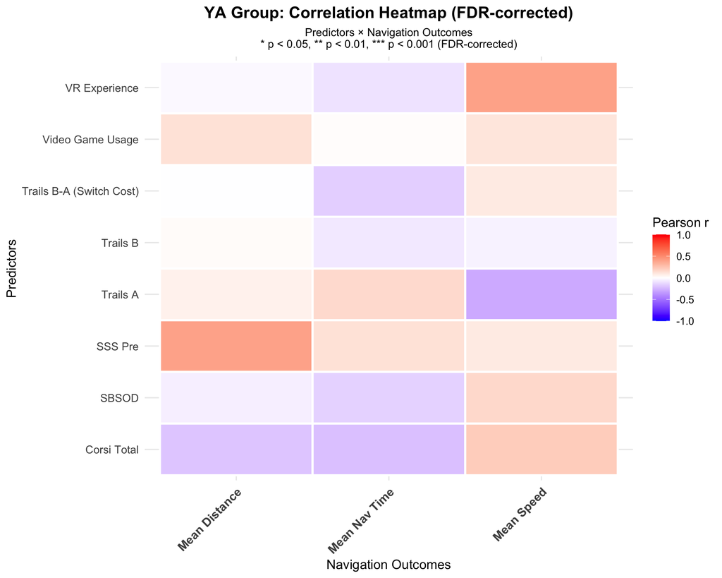

```r
# Create correlation matrix for heatmap
ya_corr_matrix <- ya_correlations %>%
  select(predictor_label, outcome_label, r) %>%
  pivot_wider(names_from = outcome_label, values_from = r) %>%
  column_to_rownames("predictor_label") %>%
  as.matrix()

ya_pval_matrix <- ya_correlations %>%
  select(predictor_label, outcome_label, p_fdr) %>%
  pivot_wider(names_from = outcome_label, values_from = p_fdr) %>%
  column_to_rownames("predictor_label") %>%
  as.matrix()

# Create significance annotations (using FDR-corrected p-values)
ya_sig_text <- matrix("", nrow = nrow(ya_pval_matrix), ncol = ncol(ya_pval_matrix))
rownames(ya_sig_text) <- rownames(ya_pval_matrix)
colnames(ya_sig_text) <- colnames(ya_pval_matrix)
ya_sig_text[ya_pval_matrix < 0.001] <- "***"
ya_sig_text[ya_pval_matrix >= 0.001 & ya_pval_matrix < 0.01] <- "**"
ya_sig_text[ya_pval_matrix >= 0.01 & ya_pval_matrix < 0.05] <- "*"

# Prepare data for ggplot
ya_corr_df <- as.data.frame(ya_corr_matrix) %>%
  rownames_to_column("Predictor") %>%
  pivot_longer(cols = -Predictor, names_to = "Outcome", values_to = "correlation")

ya_sig_df <- as.data.frame(ya_sig_text, stringsAsFactors = FALSE) %>%
  rownames_to_column("Predictor") %>%
  pivot_longer(cols = -Predictor, names_to = "Outcome", values_to = "sig")

plot_data <- ya_corr_df %>%
  left_join(ya_sig_df, by = c("Predictor", "Outcome"))

# Create heatmap
ggplot(plot_data, aes(x = Outcome, y = Predictor, fill = correlation)) +
  geom_tile(color = "white", size = 1) +
  geom_text(aes(label = sig), size = 6, vjust = 0.7, fontface = "bold") +
  scale_fill_gradient2(
    low = "blue", mid = "white", high = "red",
    midpoint = 0, limit = c(-1, 1), na.value = "grey90",
    name = "Pearson r"
  ) +
  theme_minimal(base_size = 13) +
  labs(
    title = "YA Group: Correlation Heatmap (FDR-corrected)",
    subtitle = "Predictors × Navigation Outcomes\n* p < 0.05, ** p < 0.01, *** p < 0.001 (FDR-corrected)",
    x = "Navigation Outcomes",
    y = "Predictors"
  ) +
  theme(
    axis.text.x = element_text(angle = 45, hjust = 1, size = 12, face = "bold"),
    axis.text.y = element_text(size = 11),
    plot.title = element_text(hjust = 0.5, size = 16, face = "bold"),
    plot.subtitle = element_text(hjust = 0.5, size = 11),
    legend.position = "right"
  )
```

# OA Group Correlations with FDR Correction

```r
cat("=== OLDER ADULTS (OA) CORRELATIONS ===\n\n")
```

```
## === OLDER ADULTS (OA) CORRELATIONS ===
```

```r
# Filter OA data
oa_data <- merged_data %>% filter(Group == "OA")

cat("OA sample size:", nrow(oa_data), "\n\n")
```

```
## OA sample size: 30
```

```r
# Compute all OA correlations
oa_correlations <- compute_correlations(oa_data, predictors, outcomes)

# Add FDR correction within OA group
oa_correlations <- oa_correlations %>%
  mutate(
    p_fdr = p.adjust(p_value, method = "fdr")
  )

# Add labels
oa_correlations <- oa_correlations %>%
  mutate(
    predictor_label = predictor_labels[match(predictor, predictors)],
    outcome_label = outcome_labels[match(outcome, outcomes)]
  )

# Display correlation table
cat("OA Correlation Results (with FDR correction):\n\n")
```

```
## OA Correlation Results (with FDR correction):
```

```r
oa_correlations %>%
  select(Predictor = predictor_label,
         Outcome = outcome_label,
         r, p_raw = p_value, p_fdr, n) %>%
  mutate(
    r = round(r, 3),
    p_raw = format(p_raw, scientific = FALSE, digits = 4),
    p_fdr = format(p_fdr, scientific = FALSE, digits = 4),
    sig_raw = case_when(
      as.numeric(p_raw) < 0.001 ~ "***",
      as.numeric(p_raw) < 0.01 ~ "**",
      as.numeric(p_raw) < 0.05 ~ "*",
      TRUE ~ ""
    ),
    sig_fdr = case_when(
      as.numeric(p_fdr) < 0.001 ~ "***",
      as.numeric(p_fdr) < 0.01 ~ "**",
      as.numeric(p_fdr) < 0.05 ~ "*",
      TRUE ~ ""
    )
  ) %>%
  kable(caption = "OA Group: Correlations with Raw and FDR-Corrected P-values") %>%
  kable_styling(bootstrap_options = c("striped", "hover", "condensed")) %>%
  scroll_box(height = "600px")
```

OA Group: Correlations with Raw and FDR-Corrected P-values

Predictor

Outcome

r

p_raw

p_fdr

n

sig_raw

sig_fdr

VR Experience

Mean Speed

0.123

0.51684

0.8677

30

VR Experience

Mean Distance

-0.015

0.93791

0.9700

30

VR Experience

Mean Nav Time

-0.150

0.42962

0.8242

30

Video Game Usage

Mean Speed

-0.007

0.97000

0.9700

30

Video Game Usage

Mean Distance

0.098

0.60687

0.8677

30

Video Game Usage

Mean Nav Time

0.164

0.38569

0.8242

30

SSS Pre

Mean Speed

-0.066

0.72830

0.8677

30

SSS Pre

Mean Distance

-0.058

0.75925

0.8677

30

SSS Pre

Mean Nav Time

-0.030

0.87410

0.9536

30

SBSOD

Mean Speed

0.215

0.25448

0.8242

30

SBSOD

Mean Distance

-0.311

0.09453

0.5958

30

SBSOD

Mean Nav Time

-0.318

0.08690

0.5958

30

Trails A

Mean Speed

-0.307

0.09931

0.5958

30

Trails A

Mean Distance

0.080

0.67399

0.8677

30

Trails A

Mean Nav Time

0.144

0.44645

0.8242

30

Trails B

Mean Speed

-0.209

0.26781

0.8242

30

Trails B

Mean Distance

0.088

0.64224

0.8677

30

Trails B

Mean Nav Time

0.183

0.33295

0.8242

30

Trails B-A (Switch Cost)

Mean Speed

-0.149

0.43099

0.8242

30

Trails B-A (Switch Cost)

Mean Distance

0.076

0.68948

0.8677

30

Trails B-A (Switch Cost)

Mean Nav Time

0.163

0.38923

0.8242

30

Corsi Total

Mean Speed

0.387

0.03463

0.5958

30

Corsi Total

Mean Distance

-0.104

0.58606

0.8677

30

Corsi Total

Mean Nav Time

-0.233

0.21487

0.8242

30

```r
# Count significant correlations
oa_sig_summary <- oa_correlations %>%
  summarise(
    total = n(),
    raw_p_05 = sum(p_value < 0.05, na.rm = TRUE),
    raw_p_01 = sum(p_value < 0.01, na.rm = TRUE),
    raw_p_001 = sum(p_value < 0.001, na.rm = TRUE),
    fdr_p_05 = sum(p_fdr < 0.05, na.rm = TRUE),
    fdr_p_01 = sum(p_fdr < 0.01, na.rm = TRUE),
    fdr_p_001 = sum(p_fdr < 0.001, na.rm = TRUE)
  )

cat("\n\nOA Significant Correlations (Raw p-values):\n")
```

```
##
##
## OA Significant Correlations (Raw p-values):
```

```r
cat("p < 0.05:", oa_sig_summary$raw_p_05, "out of", oa_sig_summary$total, "\n")
```

```
## p < 0.05: 1 out of 24
```

```r
cat("p < 0.01:", oa_sig_summary$raw_p_01, "out of", oa_sig_summary$total, "\n")
```

```
## p < 0.01: 0 out of 24
```

```r
cat("p < 0.001:", oa_sig_summary$raw_p_001, "out of", oa_sig_summary$total, "\n")
```

```
## p < 0.001: 0 out of 24
```

```r
cat("\n\nOA Significant Correlations (FDR-corrected):\n")
```

```
##
##
## OA Significant Correlations (FDR-corrected):
```

```r
cat("p < 0.05:", oa_sig_summary$fdr_p_05, "out of", oa_sig_summary$total, "\n")
```

```
## p < 0.05: 0 out of 24
```

```r
cat("p < 0.01:", oa_sig_summary$fdr_p_01, "out of", oa_sig_summary$total, "\n")
```

```
## p < 0.01: 0 out of 24
```

```r
cat("p < 0.001:", oa_sig_summary$fdr_p_001, "out of", oa_sig_summary$total, "\n")
```

```
## p < 0.001: 0 out of 24
```

## OA Correlation Heatmap (FDR-corrected)

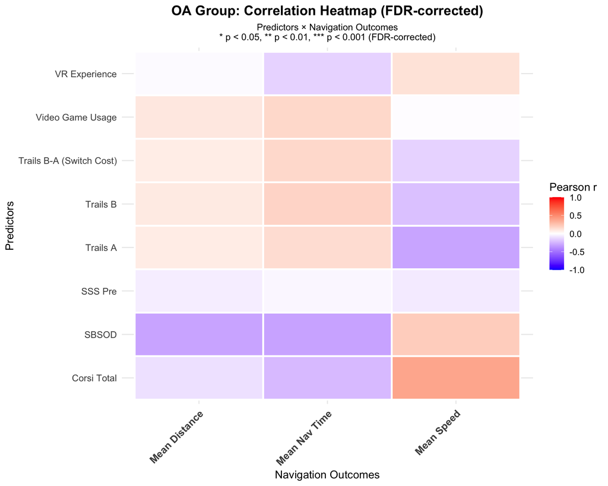

```r
# Create correlation matrix for heatmap
oa_corr_matrix <- oa_correlations %>%
  select(predictor_label, outcome_label, r) %>%
  pivot_wider(names_from = outcome_label, values_from = r) %>%
  column_to_rownames("predictor_label") %>%
  as.matrix()

oa_pval_matrix <- oa_correlations %>%
  select(predictor_label, outcome_label, p_fdr) %>%
  pivot_wider(names_from = outcome_label, values_from = p_fdr) %>%
  column_to_rownames("predictor_label") %>%
  as.matrix()

# Create significance annotations (using FDR-corrected p-values)
oa_sig_text <- matrix("", nrow = nrow(oa_pval_matrix), ncol = ncol(oa_pval_matrix))
oa_sig_text[oa_pval_matrix < 0.001] <- "***"
oa_sig_text[oa_pval_matrix >= 0.001 & oa_pval_matrix < 0.01] <- "**"
oa_sig_text[oa_pval_matrix >= 0.01 & oa_pval_matrix < 0.05] <- "*"

# Prepare data for ggplot
oa_corr_long <- melt(oa_corr_matrix, value.name = "correlation")
oa_sig_long <- melt(oa_sig_text, value.name = "sig")

# Convert factors to character
oa_corr_long <- oa_corr_long %>%
  mutate(Var1 = as.character(Var1), Var2 = as.character(Var2))
oa_sig_long <- oa_sig_long %>%
  mutate(Var1 = as.character(Var1), Var2 = as.character(Var2))

plot_data <- oa_corr_long %>%
  left_join(oa_sig_long, by = c("Var1", "Var2"))

# Create heatmap
ggplot(plot_data, aes(x = Var2, y = Var1, fill = correlation)) +
  geom_tile(color = "white", size = 1) +
  geom_text(aes(label = sig), size = 6, vjust = 0.7, fontface = "bold") +
  scale_fill_gradient2(
    low = "blue", mid = "white", high = "red",
    midpoint = 0, limit = c(-1, 1), na.value = "grey90",
    name = "Pearson r"
  ) +
  theme_minimal(base_size = 13) +
  labs(
    title = "OA Group: Correlation Heatmap (FDR-corrected)",
    subtitle = "Predictors × Navigation Outcomes\n* p < 0.05, ** p < 0.01, *** p < 0.001 (FDR-corrected)",
    x = "Navigation Outcomes",
    y = "Predictors"
  ) +
  theme(
    axis.text.x = element_text(angle = 45, hjust = 1, size = 12, face = "bold"),
    axis.text.y = element_text(size = 11),
    plot.title = element_text(hjust = 0.5, size = 16, face = "bold"),
    plot.subtitle = element_text(hjust = 0.5, size = 11),
    legend.position = "right"
  )
```

# Summary Comparison

```r
cat("=== SUMMARY: YA vs OA CORRELATIONS (FDR-corrected) ===\n\n")
```

```
## === SUMMARY: YA vs OA CORRELATIONS (FDR-corrected) ===
```

```r
# Combine results for comparison
combined_summary <- bind_rows(
  ya_sig_summary %>% mutate(Group = "YA"),
  oa_sig_summary %>% mutate(Group = "OA")
) %>%
  select(Group, total,
         raw_p_05, raw_p_01, raw_p_001,
         fdr_p_05, fdr_p_01, fdr_p_001)

cat("Significant Correlations by Group:\n")
```

```
## Significant Correlations by Group:
```

```r
print(combined_summary)
```

```
## # A tibble: 2 × 8
##   Group total raw_p_05 raw_p_01 raw_p_001 fdr_p_05 fdr_p_01 fdr_p_001
##   <chr> <int>    <int>    <int>     <int>    <int>    <int>     <int>
## 1 YA       24        2        0         0        0        0         0
## 2 OA       24        1        0         0        0        0         0
```

```r
# Identify strongest correlations that survive FDR correction
cat("\n\nStrongest FDR-Significant Positive Correlations:\n\n")
```

```
##
##
## Strongest FDR-Significant Positive Correlations:
```

```r
cat("YA Group:\n")
```

```
## YA Group:
```

```r
ya_correlations %>%
  filter(p_fdr < 0.05) %>%
  arrange(desc(r)) %>%
  head(5) %>%
  select(Predictor = predictor_label, Outcome = outcome_label, r, p_fdr, n) %>%
  mutate(r = round(r, 3), p_fdr = round(p_fdr, 4)) %>%
  kable() %>%
  kable_styling()
```

[output not shown]

```r
cat("\n\nOA Group:\n")
```

```
##
##
## OA Group:
```

```r
oa_correlations %>%
  filter(p_fdr < 0.05) %>%
  arrange(desc(r)) %>%
  head(5) %>%
  select(Predictor = predictor_label, Outcome = outcome_label, r, p_fdr, n) %>%
  mutate(r = round(r, 3), p_fdr = round(p_fdr, 4)) %>%
  kable() %>%
  kable_styling()
```

[output not shown]

```r
cat("\n\nStrongest FDR-Significant Negative Correlations:\n\n")
```

```
##
##
## Strongest FDR-Significant Negative Correlations:
```

```r
cat("YA Group:\n")
```

```
## YA Group:
```

```r
ya_correlations %>%
  filter(p_fdr < 0.05) %>%
  arrange(r) %>%
  head(5) %>%
  select(Predictor = predictor_label, Outcome = outcome_label, r, p_fdr, n) %>%
  mutate(r = round(r, 3), p_fdr = round(p_fdr, 4)) %>%
  kable() %>%
  kable_styling()
```

[output not shown]

```r
cat("\n\nOA Group:\n")
```

```
##
##
## OA Group:
```

```r
oa_correlations %>%
  filter(p_fdr < 0.05) %>%
  arrange(r) %>%
  head(5) %>%
  select(Predictor = predictor_label, Outcome = outcome_label, r, p_fdr, n) %>%
  mutate(r = round(r, 3), p_fdr = round(p_fdr, 4)) %>%
  kable() %>%
  kable_styling()
```

[output not shown]